# R Summer Assignment – Part 4

YOUR NAME

20 May, 2026

[figure not shown]

**Summer 2026, Pre-Assignment**

**Part 4: Data Manipulation: Part 2**

**Estimated time:** 2-4 hours

1. **Preparation**: Please complete these official RStudio tutorials before starting this notebook. We strongly recommend taking notes below and typing in the code yourself as you follow this tutorial.
- **WATCH**:
  - [dplyr essentials](https://youtu.be/Gvhkp-Yw65U)
  - [dplyr advanced guide](https://youtu.be/DiY8EqZDwoI) (Optional)
2. Use the following [FAQs](https://docs.google.com/document/d/1sec_uWmFXWi0WOnecd1JoLqulhEpEvYY52zvCcMNlF4/edit?usp=sharing) in case of doubts. Any other questions? Post them on Slack.

**Using AI while learning R:** AI tools can help you remember syntax for `group_by()`, `summarise()`, or a graphing function. They cannot decide whether your denominator, grouping level, or interpretation is correct. Always check what one row represents before and after you summarize.

> In previous notebooks, we have generally edited components of datasets while keeping the larger dataset structure the same. Often, we will want to calculate **statistics** from datasets that involve generating new information from our dataset in some way.

```r
# If needed:
# TAKE NOTES HERE for the Primers
```

# 1. When to summarize?

Often, we will want to **aggregate** information across a dataset or across groups in a dataset. For example, adding the total number of votes in every polling place, or the average outcome in each group in a randomized trial. Using our `state` population data from last time, imagine we wanted to plot the total US population over time.

```r
# INSTALLATION CODE:

options(repos = c(CRAN = "https://cloud.r-project.org"))

if(!("tidyverse" %in% rownames(installed.packages()))) {
  install.packages("tidyverse")
}

library(tidyverse)

# This code sets a simple plot style for the examples below.
# It will make more sense later in the semester.
options(repr.plot.width = 10, repr.plot.height = 7)

hks_blue <- "#1F5F83"
hks_crimson <- "#A51C30"

theme_set(
  theme_minimal(base_size = 13) +
    theme(
      plot.title = element_text(face = "bold", size = 16),
      plot.subtitle = element_text(color = "gray35"),
      panel.grid.minor = element_blank(),
      strip.text = element_text(face = "bold"),
      axis.title = element_text(face = "bold")
    )
)
update_geom_defaults("point", list(size = 2.2, alpha = 0.8))
update_geom_defaults("line", list(linewidth = 1.1))

# read in the data
state <- read_csv("https://www.dropbox.com/s/javbnd4c3n67380/state_population.csv?dl=1")
# see the first 5 rows of the data
head(state)
```

```
## # A tibble: 6 × 5
##   state  year population region after2000
##   <chr> <dbl>      <dbl> <chr>  <lgl>
## 1 AK     1950     135000 West   FALSE
## 2 AK     1951     158000 West   FALSE
## 3 AK     1952     189000 West   FALSE
## 4 AK     1953     205000 West   FALSE
## 5 AK     1954     215000 West   FALSE
## 6 AK     1955     222000 West   FALSE
```

```r
cat("Done!")
```

```
## Done!
```

We could plot every state at once, but this would not tell us the total US population by year. Since the rows in our dataset are state populations in one particular year, this plot will plot every state as its own sequence of points in a scatterplot.

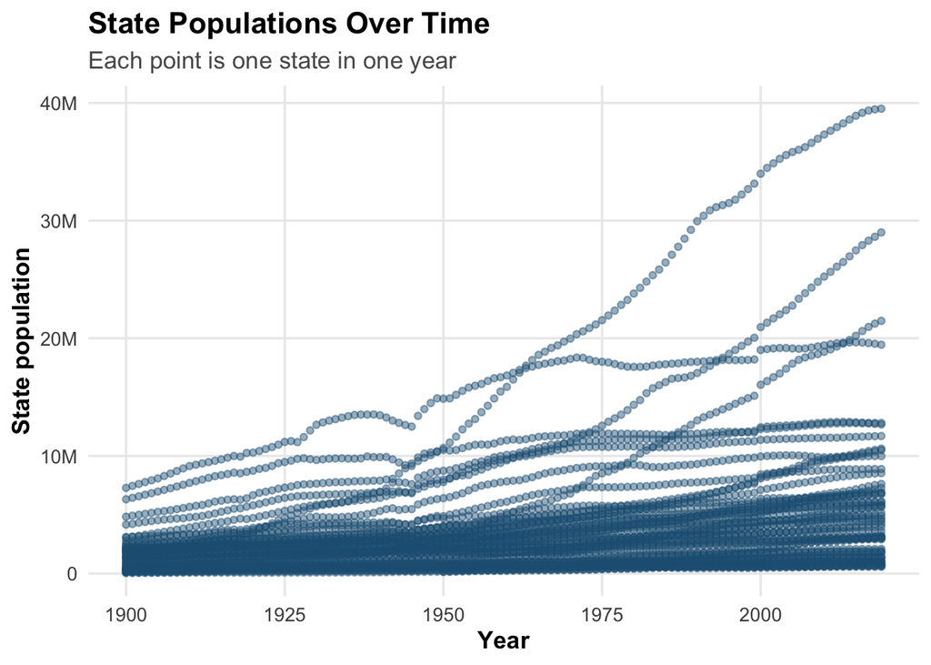

```r
state |>
  ggplot(
    aes(
      x = year,
      y = population
    )
  ) +
  geom_point(color = hks_blue, alpha = 0.45, size = 1.4) +
  scale_y_continuous(labels = scales::label_number(scale_cut = scales::cut_short_scale())) +
  labs(
    x = "Year",
    y = "State population",
    title = "State Populations Over Time",
    subtitle = "Each point is one state in one year"
  )
```

What if we want to know the **total population by year**? We already have the tools we need to do this for a single year.

How? We could `filter()` the dataset to a certain year, and then use `sum()` on the `population` column. We can use the `$` syntax after the name of a dataset to access one particular column in the dataset as a vector.

For example, to calculate the US population in 1976, we could:

```r
# Filter rows to all observations in 1976
all_1976 <- state |>
  filter(year == 1976)

# Sum the population column
sum(all_1976$population)
```

```
## [1] 217562732
```

So, according to this dataset the US population in 1976 was a little over 200 million.

# Quick Exercise

First, try it yourself. Try calculating the population of only the US South in the year 1980.

```r
# Write your code here.
```

# group_by() and summarise()

The above process was a little tedious though. How might we calculate this total for **every year** in our dataset? We could replicate the above procedure many times, or perhaps create a function and run it once for each year.

Instead, R makes this sort of repetition with the functions `group_by()` and `summarise()`. When used together, `group_by()` defines a group and `summarise()` will perform a calculation within each of those groups. If you are familiar with Excel, this idea is conceptually similar to a Pivot Table. You will see that R allows for much more flexible and complex calculations.

For example, this code will run the `sum()` function on the `population` column within each group (`year`):

```r
# Within each group (year)
# calculate the total population
pop_by_year <- state |>
  group_by(year) |>
  summarise(pop = sum(population))

# tail() shows the final rows in the dataset
head(pop_by_year)
```

```
## # A tibble: 6 × 2
##    year      pop
##   <dbl>    <dbl>
## 1  1900 76095000
## 2  1901 77588000
## 3  1902 79160000
## 4  1903 80631000
## 5  1904 82165000
## 6  1905 83818000
```

Notice that the unit of analysis changed. In `state`, one row is a state-year. In `pop_by_year`, one row is a year. This is why checking the rows after `summarise()` is so important.

```r
nrow(state)
```

```
## [1] 6020
```

```r
nrow(pop_by_year)
```

```
## [1] 120
```

The function `n()` counts how many rows are in each group. This is useful for checking whether each summary is based on the number of observations you expected.

```r
state |>
  group_by(year) |>
  summarise(
    pop = sum(population),
    n_states = n()
  )
```

```
## # A tibble: 120 × 3
##     year      pop n_states
##    <dbl>    <dbl>    <int>
##  1  1900 76095000       49
##  2  1901 77588000       49
##  3  1902 79160000       49
##  4  1903 80631000       49
##  5  1904 82165000       49
##  6  1905 83818000       49
##  7  1906 85439000       49
##  8  1907 87001000       49
##  9  1908 88706000       49
## 10  1909 90490000       49
## # ℹ 110 more rows
```

Now that we have that object, we can plot total US population by year directly. How should we visualize this data? Building on what we learned in our last lesson, we have a lot of options. Let’s start with a simple bar plot:

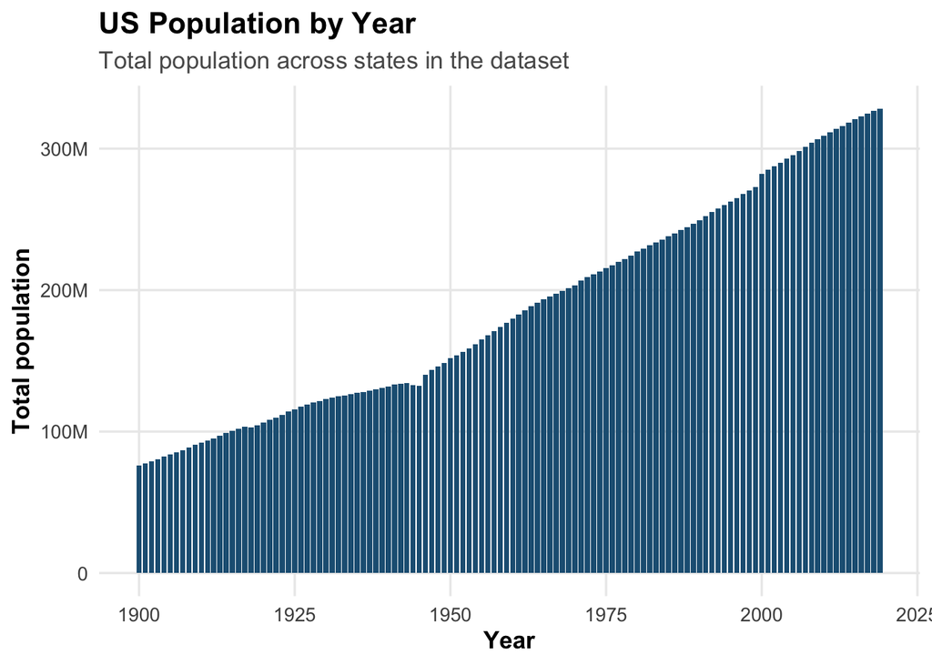

```r
# simple bar plot
pop_by_year |>
  ggplot(
    aes(
      x = year,
      y = pop
    )
  ) +
  geom_col(fill = hks_blue, width = 0.85) +
  scale_y_continuous(labels = scales::label_number(scale_cut = scales::cut_short_scale())) +
  labs(
    x = "Year",
    y = "Total population",
    title = "US Population by Year",
    subtitle = "Total population across states in the dataset"
  )
```

Another option would be to try to draw the viewer’s attention to the top of the bar by placing points on top. These are often called ‘lollipop plots,’ and can be made by creating a line segment and a `geom_point()`.

Want to learn more about the `geom_segment()` function? One very useful skill when learning to program is learning to read documentation. Take a look at [this help page](https://ggplot2.tidyverse.org/reference/geom_segment.html) for the `geom_segment()` function and try to read through what each argument below does.

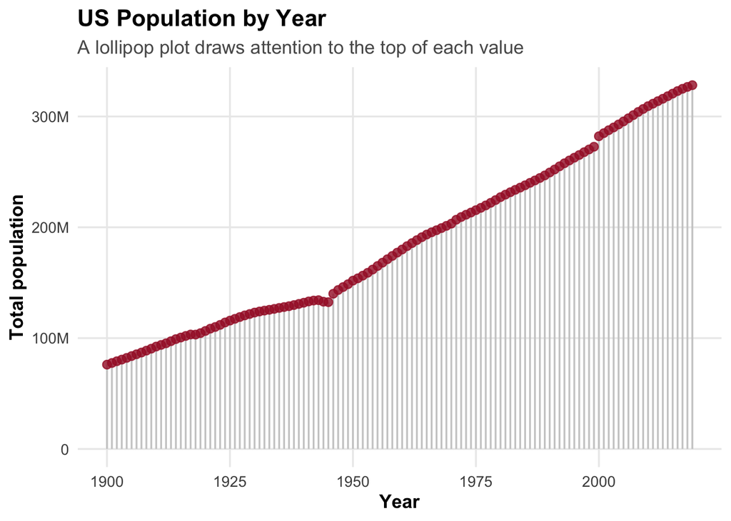

```r
# a "lollipop" plot
# combines straight line segment with point
pop_by_year |>
  ggplot(
    aes(
      x = year,
      y = pop
    )
  ) +
  geom_segment(aes(x = year, xend = year, y = 0, yend = pop), color = "gray80") +
  geom_point(color = hks_crimson, size = 2.4) +
  scale_y_continuous(labels = scales::label_number(scale_cut = scales::cut_short_scale())) +
  labs(
    x = "Year",
    y = "Total population",
    title = "US Population by Year",
    subtitle = "A lollipop plot draws attention to the top of each value"
  )
```

You can also **define groups by multiple variables**. This is useful when you want to calculate a particular statistic within groups defined by more than one variable. For example, to calculate population separately by **region** AND **year**.

```r
region_year <- state |>
  group_by(region, year) |> # group_by multiple columns
  summarise(pop = sum(population))
```

```
## `summarise()` has regrouped the output.
## ℹ Summaries were computed grouped by region and year.
## ℹ Output is grouped by region.
## ℹ Use `summarise(.groups = "drop_last")` to silence this message.
## ℹ Use `summarise(.by = c(region, year))` for per-operation grouping
##   (`?dplyr::dplyr_by`) instead.
```

```r
region_year |> filter(year == 1900)
```

```
## # A tibble: 4 × 3
## # Groups:   region [4]
##   region     year      pop
##   <chr>     <dbl>    <dbl>
## 1 Midwest    1900 26359000
## 2 Northeast  1900 21059000
## 3 South      1900 24565000
## 4 West       1900  4112000
```

Now, we could use a facet like we learned in the previous lesson to visualize the growth in each region at once.

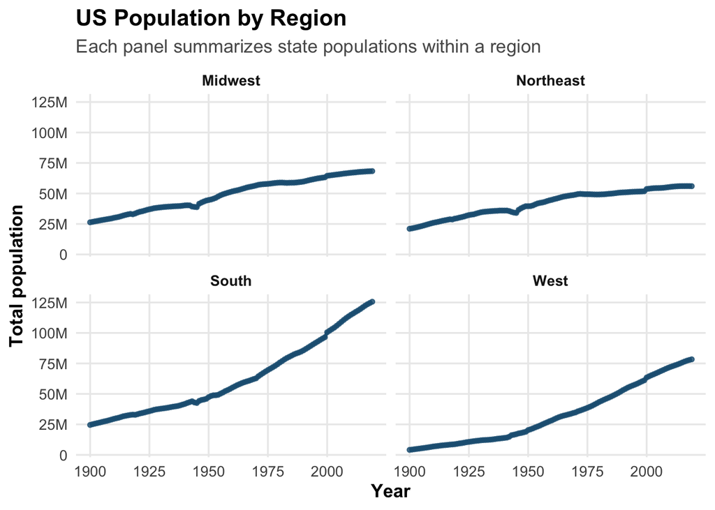

```r
region_year |>
  ggplot(aes(x = year, y = pop)) +
  geom_line(color = hks_blue) +
  geom_point(color = hks_blue, size = 1.2) +
  scale_y_continuous(labels = scales::label_number(scale_cut = scales::cut_short_scale())) +
  labs(
    x = "Year",
    y = "Total population",
    title = "US Population by Region",
    subtitle = "Each panel summarizes state populations within a region"
  ) +
  facet_wrap(~region)
```

## Exercises #1

This dataset contains information on World Cup matches from 1930 to 2006. The `scored` column contains information on each national team’s performance in a particular World Cup.

```r
cups <- read_csv("https://www.dropbox.com/s/eb74w6516hvm11a/world_cups%20-%20WorldCups.csv?dl=1")
```

1. Look at the data with a function like `head()`.

```r
# Write your code here.
```

2. Then, using `group_by()` and `summarise()`, calculate the total number of goals that each team has scored across all World Cups. Save this to an object named `goals`.

```r
# Write your code here.
```

3. Filter to only teams that have scored at least 50 goals in total from the `goals` object. Save this in an object called `high_score_teams`.

```r
# Write your code here.
```

4. Design a plot visualizing the number of goals scored by each team using `high_score_teams`. The plot can be as simple (or as sophisticated) as you want as long as it conveys clearly the main findings you want the reader to derive.

```r
# Write your code here.
```

In one sentence, describe the main finding from your plot. Then write one sentence about whether the plot makes comparison across teams easy or difficult.

Write your answer here:

# Using groups for other statistics

The sum is one interesting measurement you will want to calculate, but it is certainly not the only one. The **mean** (average) is another. Thankfully, calculating means for the complete sample or finding means within each group is very simple. All you need to do is change the function that you use in `summarise()`.

Take a look at the examples below. We recommend running each section of code separately and trying to edit them yourself. Calculate other statistics you think might be interesting. Any questions or trouble? Post in the Slack!

```r
# find total number of goals scored for each team
cups |>
  group_by(team) |>
  summarise(scored = sum(scored))
```

```
## # A tibble: 77 × 2
##    team      scored
##    <chr>      <dbl>
##  1 Algeria        6
##  2 Angola         1
##  3 Argentina    113
##  4 Australia      5
##  5 Austria       43
##  6 Belgium       46
##  7 Bolivia        1
##  8 Brazil       201
##  9 Bulgaria      22
## 10 Cameroon      15
## # ℹ 67 more rows
```

```r
# find average number of goals scored by team in each World Cup
# consider: why might a statistic like this not be very useful for all teams?
cups |>
  group_by(team) |>
  summarise(scored = mean(scored))
```

```
## # A tibble: 77 × 2
##    team      scored
##    <chr>      <dbl>
##  1 Algeria    3
##  2 Angola     1
##  3 Argentina  8.07
##  4 Australia  2.5
##  5 Austria    6.14
##  6 Belgium    4.18
##  7 Bolivia    0.333
##  8 Brazil    11.2
##  9 Bulgaria   3.14
## 10 Cameroon   3
## # ℹ 67 more rows
```

Using `summarise()` without any groups created by `group_by()` before will summarize the entire dataset. For example:

```r
# find total number of goals scored in 1930 World Cup
cups |>
  filter(year == 1930) |>
  summarise(scored = sum(scored))
```

```
## # A tibble: 1 × 1
##   scored
##    <dbl>
## 1     70
```

```r
# find average goals scored per match in 1930 World Cup
cups |>
  filter(year == 1930) |>
  summarise(scored = mean(scored / matches))
```

```
## # A tibble: 1 × 1
##   scored
##    <dbl>
## 1   1.64
```

Be careful with averages. The average of team-level rates is not always the same as the overall rate. In the code below, the unweighted mean treats every team equally, while the weighted rate gives more influence to teams with more matches.

```r
cups |>
  filter(year == 1930) |>
  summarise(
    unweighted_goals_per_match = mean(scored / matches),
    weighted_goals_per_match = sum(scored) / sum(matches)
  )
```

```
## # A tibble: 1 × 2
##   unweighted_goals_per_match weighted_goals_per_match
##                        <dbl>                    <dbl>
## 1                       1.64                     1.94
```

If an AI tool suggests a summary statistic, check whether it is using the right level of aggregation and the right denominator.

The **median** of a set of numbers is found by ordering them from smallest to largest and finding the value in the middle. Means and medians are both ways of estimating the center of a dataset, but they do have important differences in some cases. For example:

```r
numbers <- c(1, 3, 7, 9, 2000)
# notice how the mean is sensitive to outliers
mean(numbers)
```

```
## [1] 404
```

```r
# the median is not as sensitive
median(numbers)
```

```
## [1] 7
```

```r
# consider: why might these numbers be different?
mean(cups$scored)
```

```
## [1] 5.716667
```

```r
median(cups$scored)
```

```
## [1] 4
```

When summarizing real datasets, also check for missing values before trusting a mean or median.

```r
sum(is.na(cups$scored))
```

```
## [1] 0
```

# 2. Visualizing distributions

Statistics like sums, means, and medians are one way of summarizing data, but they still only tell you one number. Sometimes, you will want to visualize all of the values in a column or two of your dataset - the entire **distribution**.

### Histograms

For example, a **histogram** will visualize all of the values in one column. Taller bars tell you that more data fit in that range:

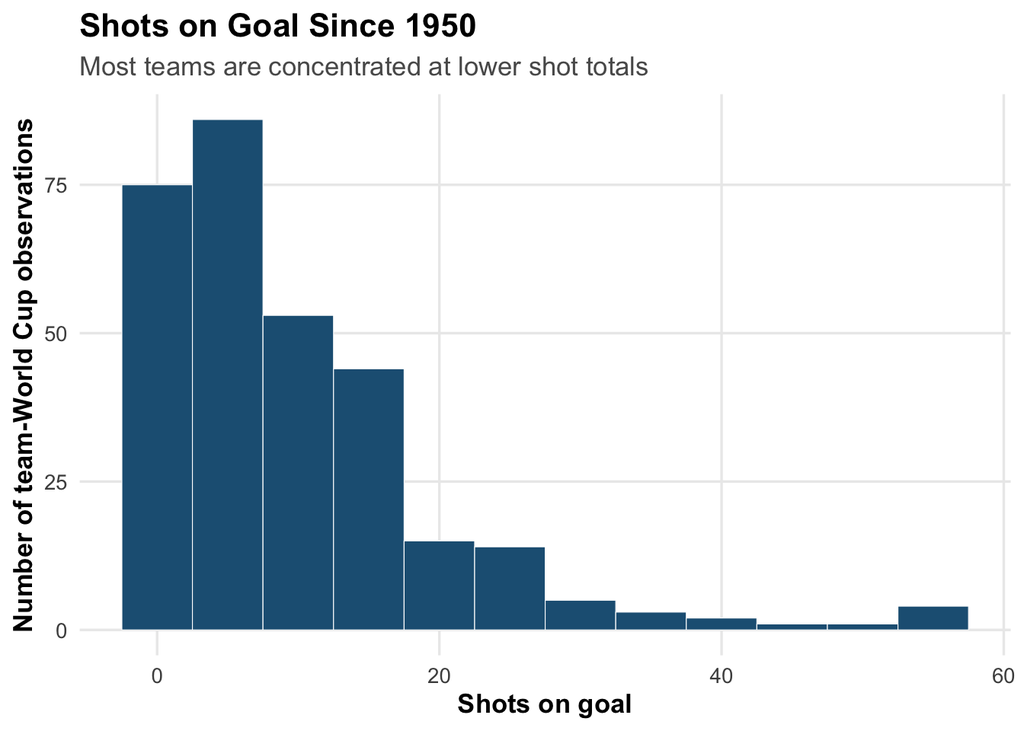

```r
# visualize shots on goal since 1950
cups |>
  filter(year > 1950) |>
  ggplot(aes(x = shots_on_goal)) +
  geom_histogram(binwidth = 5, fill = hks_blue, color = "white", linewidth = 0.2) +
  labs(
    x = "Shots on goal",
    y = "Number of team-World Cup observations",
    title = "Shots on Goal Since 1950",
    subtitle = "Most teams are concentrated at lower shot totals"
  )
```

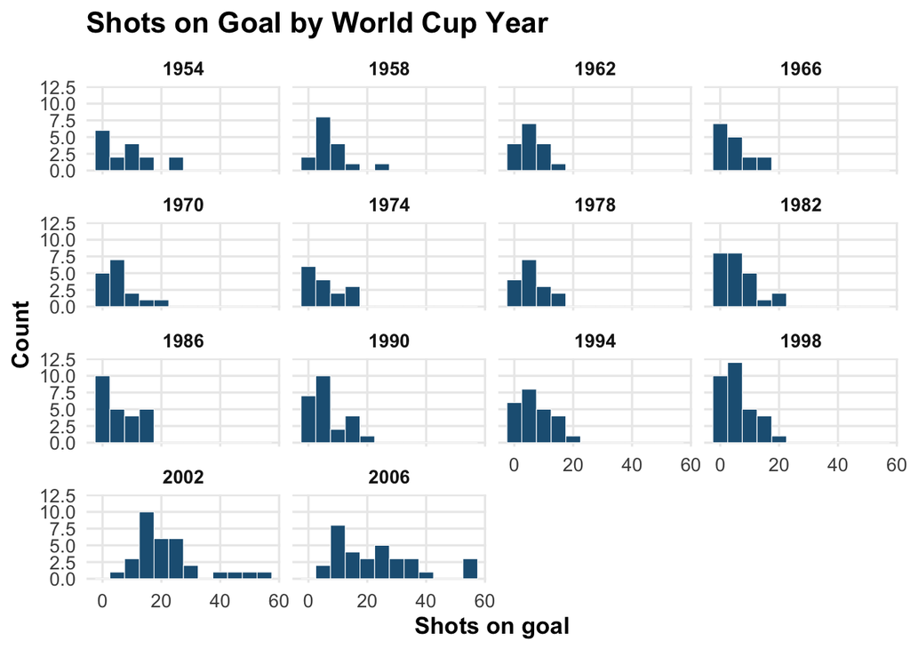

```r
# just like any other geom, can use with groups and facets
cups |>
  filter(year > 1950) |>
  ggplot(aes(x = shots_on_goal)) +
  geom_histogram(binwidth = 5, fill = hks_blue, color = "white", linewidth = 0.2) +
  labs(
    x = "Shots on goal",
    y = "Count",
    title = "Shots on Goal by World Cup Year"
  ) +
  facet_wrap(~year)
```

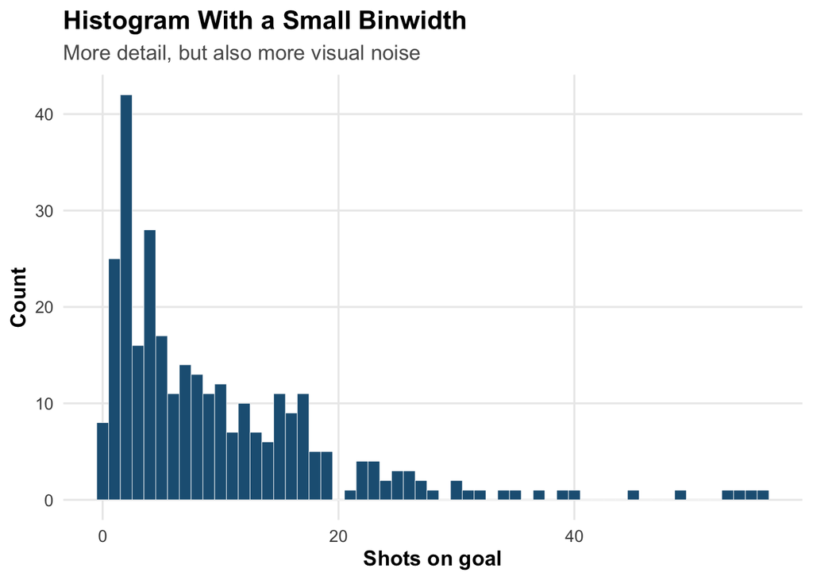

```r
# very small binwidth
cups |>
  filter(year > 1950) |>
  ggplot(aes(x = shots_on_goal)) +
  geom_histogram(binwidth = 1, fill = hks_blue, color = "white", linewidth = 0.15) +
  labs(
    x = "Shots on goal",
    y = "Count",
    title = "Histogram With a Small Binwidth",
    subtitle = "More detail, but also more visual noise"
  )
```

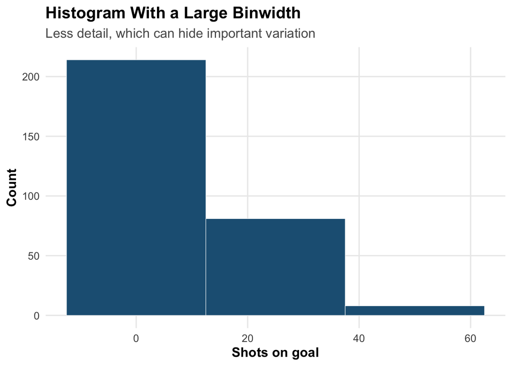

```r
# very large binwidth - not as informative!
cups |>
  filter(year > 1950) |>
  ggplot(aes(x = shots_on_goal)) +
  geom_histogram(binwidth = 25, fill = hks_blue, color = "white", linewidth = 0.2) +
  labs(
    x = "Shots on goal",
    y = "Count",
    title = "Histogram With a Large Binwidth",
    subtitle = "Less detail, which can hide important variation"
  )
```

## Exercises #2

1. Read in the `elections` data from the previous notebook. Then, create a histogram to visualize Democratic performance in all elections since and including 1992 (`>= 1992`) with one plot for each region.

For an extra challenge, try adding a vertical line to the plot at 50 with the `geom_vline()` function (you can read the documentation for a function with `?geom_vline` or by Googling “R `geom_vline()`, then scroll down to”Examples” to see code examples using the function).

Finally, explain the general trend that you see.

In your explanation, describe the center, spread, skew, and any visible outliers or regional differences. If changing the binwidth changes your conclusion, say so.

```r
elections <- read_csv("https://www.dropbox.com/s/lhp9nets5qb2rhe/presidential_elections.csv?dl=1")
```

2. Using **only results from states in the South**, create a histogram for `democrat` with one plot per year. Try adding a vertical line at 50 as described above.

```r
# Write your code here.
```

Here, in text describe the trend you see over time!

3. Think about the trend you saw in Question 2. Clearly describe it. Discuss a way you might visualize that trend. If you have time, try designing a plot to do so.

Type answer here!

## What you should know after this part

By the end of Part 4, you should be able to:

- Use `group_by()` and `summarise()` to calculate grouped statistics.
- Explain how summarizing changes the unit of analysis.
- Use `n()` to check how many rows are in each group.
- Compare means and medians, including when outliers matter.
- Describe the center, spread, skew, and outliers in a distribution.

## Before you submit

- Knit the notebook successfully.
- Answer every written question in your own words.
- Save your completed `.Rmd` file.
- Submit the correct `.Rmd` file to Canvas.

## Reminder to Submit

Please follow the submission instructions listed [here](https://docs.google.com/document/d/195R1jrfbKN5lYZKT2BrU0cJB0Z1JftG8vSZ-60fdi0Q/edit?usp=sharing). We suggest you submit your assignments as you finish them (i.e., don’t wait until you have completed them all to submit).